# Bosch

```python
import warnings
warnings.filterwarnings('ignore')
import numpy as np
import pandas as pd
import seaborn as sns
import matplotlib.pyplot as plt
import scipy
import scipy.stats as stats
from scipy.stats import kurtosis
from scipy.stats import ttest_ind
from matplotlib import pyplot as plt
from statsmodels.stats.outliers_influence import variance_inflation_factor
```

```python
from IPython.display import HTML

HTML('''<script>
code_show=true;
function code_toggle() {
 if (code_show){
 $('div.input').hide();
 } else {
 $('div.input').show();
 }
 code_show = !code_show
}
$( document ).ready(code_toggle);
</script>
<form action="javascript:code_toggle()"><input type="submit" value="Click here to toggle on/off the raw code."></form>''')
```

## DATA DESCRIPTION

The data for this competition represents measurements of parts as they move through Bosch's production lines. Each part has a unique Id. The goal is to predict which parts will fail quality control (represented by a 'Response' = 1).

The dataset contains an extremely large number of anonymized features. Features are named according to a convention that tells you the production line, the station on the line, and a feature number. E.g. L3_S36_F3939 is a feature measured on line 3, station 36, and is feature number 3939.

On account of the large size of the dataset, we have separated the files by the type of feature they contain: numerical, categorical, and finally, a file with date features. The date features provide a timestamp for when each measurement was taken. Each date column ends in a number that corresponds to the previous feature number. E.g. the value of L0_S0_D1 is the time at which L0_S0_F0 was taken.

In addition to being one of the largest datasets (in terms of number of features) ever hosted on Kaggle, the ground truth for this competition is highly imbalanced. Together, these two attributes are expected to make this a challenging problem.

```python
# PATH TO FILE
path = "path"
path_bosch = path + 'train_numeric.csv'
```

### 1. ORIGINAL DATA

```python
# LOAD IN DATA
bosch_org = pd.read_csv(path_bosch)
bosch_org  # 1183747 x 970
```

|  | Id | L0_S0_F0 | L0_S0_F2 | L0_S0_F4 | L0_S0_F6 | L0_S0_F8 | L0_S0_F10 | L0_S0_F12 | L0_S0_F14 | L0_S0_F16 | ... | L3_S50_F4245 | L3_S50_F4247 | L3_S50_F4249 | L3_S50_F4251 | L3_S50_F4253 | L3_S51_F4256 | L3_S51_F4258 | L3_S51_F4260 | L3_S51_F4262 | Response |
| --- | --- | --- | --- | --- | --- | --- | --- | --- | --- | --- | --- | --- | --- | --- | --- | --- | --- | --- | --- | --- | --- |
| 0 | 4 | 0.030 | -0.034 | -0.197 | -0.179 | 0.118 | 0.116 | -0.015 | -0.032 | 0.020 | ... | NaN | NaN | NaN | NaN | NaN | NaN | NaN | NaN | NaN | 0 |
| 1 | 6 | NaN | NaN | NaN | NaN | NaN | NaN | NaN | NaN | NaN | ... | NaN | NaN | NaN | NaN | NaN | NaN | NaN | NaN | NaN | 0 |
| 2 | 7 | 0.088 | 0.086 | 0.003 | -0.052 | 0.161 | 0.025 | -0.015 | -0.072 | -0.225 | ... | NaN | NaN | NaN | NaN | NaN | NaN | NaN | NaN | NaN | 0 |
| 3 | 9 | -0.036 | -0.064 | 0.294 | 0.330 | 0.074 | 0.161 | 0.022 | 0.128 | -0.026 | ... | NaN | NaN | NaN | NaN | NaN | NaN | NaN | NaN | NaN | 0 |
| 4 | 11 | -0.055 | -0.086 | 0.294 | 0.330 | 0.118 | 0.025 | 0.030 | 0.168 | -0.169 | ... | NaN | NaN | NaN | NaN | NaN | NaN | NaN | NaN | NaN | 0 |
| ... | ... | ... | ... | ... | ... | ... | ... | ... | ... | ... | ... | ... | ... | ... | ... | ... | ... | ... | ... | ... | ... |
| 1183742 | 2367490 | -0.023 | 0.033 | -0.015 | -0.016 | -0.013 | 0.070 | 0.008 | -0.032 | 0.178 | ... | NaN | NaN | NaN | NaN | NaN | NaN | NaN | NaN | NaN | 0 |
| 1183743 | 2367491 | NaN | NaN | NaN | NaN | NaN | NaN | NaN | NaN | NaN | ... | NaN | NaN | NaN | NaN | NaN | NaN | NaN | NaN | NaN | 0 |
| 1183744 | 2367492 | 0.075 | 0.123 | -0.343 | -0.325 | 0.031 | 0.161 | -0.030 | -0.232 | 0.214 | ... | NaN | NaN | NaN | NaN | NaN | NaN | NaN | NaN | NaN | 0 |
| 1183745 | 2367493 | -0.062 | -0.019 | -0.179 | -0.179 | -0.100 | 0.116 | 0.000 | -0.072 | 0.025 | ... | NaN | NaN | NaN | NaN | NaN | NaN | NaN | NaN | NaN | 0 |
| 1183746 | 2367495 | -0.023 | 0.019 | -0.033 | -0.052 | 0.031 | 0.161 | 0.000 | -0.032 | -0.072 | ... | NaN | NaN | NaN | NaN | NaN | NaN | NaN | NaN | NaN | 0 |

1183747 rows × 970 columns

```python
# DROP COLUMNS WITH ALL NAN VALUES
bosch_valid_col = bosch_org.dropna(axis = 1, how = 'all') # how = 'any' means drop columns with at least one missing
                                                          # axis = 1 means column
                                                          # axis = 0 means row
bosch_valid_col
```

|  | Id | L0_S0_F0 | L0_S0_F2 | L0_S0_F4 | L0_S0_F6 | L0_S0_F8 | L0_S0_F10 | L0_S0_F12 | L0_S0_F14 | L0_S0_F16 | ... | L3_S50_F4245 | L3_S50_F4247 | L3_S50_F4249 | L3_S50_F4251 | L3_S50_F4253 | L3_S51_F4256 | L3_S51_F4258 | L3_S51_F4260 | L3_S51_F4262 | Response |
| --- | --- | --- | --- | --- | --- | --- | --- | --- | --- | --- | --- | --- | --- | --- | --- | --- | --- | --- | --- | --- | --- |
| 0 | 4 | 0.030 | -0.034 | -0.197 | -0.179 | 0.118 | 0.116 | -0.015 | -0.032 | 0.020 | ... | NaN | NaN | NaN | NaN | NaN | NaN | NaN | NaN | NaN | 0 |
| 1 | 6 | NaN | NaN | NaN | NaN | NaN | NaN | NaN | NaN | NaN | ... | NaN | NaN | NaN | NaN | NaN | NaN | NaN | NaN | NaN | 0 |
| 2 | 7 | 0.088 | 0.086 | 0.003 | -0.052 | 0.161 | 0.025 | -0.015 | -0.072 | -0.225 | ... | NaN | NaN | NaN | NaN | NaN | NaN | NaN | NaN | NaN | 0 |
| 3 | 9 | -0.036 | -0.064 | 0.294 | 0.330 | 0.074 | 0.161 | 0.022 | 0.128 | -0.026 | ... | NaN | NaN | NaN | NaN | NaN | NaN | NaN | NaN | NaN | 0 |
| 4 | 11 | -0.055 | -0.086 | 0.294 | 0.330 | 0.118 | 0.025 | 0.030 | 0.168 | -0.169 | ... | NaN | NaN | NaN | NaN | NaN | NaN | NaN | NaN | NaN | 0 |
| ... | ... | ... | ... | ... | ... | ... | ... | ... | ... | ... | ... | ... | ... | ... | ... | ... | ... | ... | ... | ... | ... |
| 1183742 | 2367490 | -0.023 | 0.033 | -0.015 | -0.016 | -0.013 | 0.070 | 0.008 | -0.032 | 0.178 | ... | NaN | NaN | NaN | NaN | NaN | NaN | NaN | NaN | NaN | 0 |
| 1183743 | 2367491 | NaN | NaN | NaN | NaN | NaN | NaN | NaN | NaN | NaN | ... | NaN | NaN | NaN | NaN | NaN | NaN | NaN | NaN | NaN | 0 |
| 1183744 | 2367492 | 0.075 | 0.123 | -0.343 | -0.325 | 0.031 | 0.161 | -0.030 | -0.232 | 0.214 | ... | NaN | NaN | NaN | NaN | NaN | NaN | NaN | NaN | NaN | 0 |
| 1183745 | 2367493 | -0.062 | -0.019 | -0.179 | -0.179 | -0.100 | 0.116 | 0.000 | -0.072 | 0.025 | ... | NaN | NaN | NaN | NaN | NaN | NaN | NaN | NaN | NaN | 0 |
| 1183746 | 2367495 | -0.023 | 0.019 | -0.033 | -0.052 | 0.031 | 0.161 | 0.000 | -0.032 | -0.072 | ... | NaN | NaN | NaN | NaN | NaN | NaN | NaN | NaN | NaN | 0 |

1183747 rows × 970 columns

## 2. MISSINGNESS

```python
# SUMMARIZE MISSINGNESS
mis_num = bosch_org.isna().sum()
mis_perc = mis_num/len(bosch_org)
mis_sum = pd.concat([mis_num, mis_perc], axis = 1)
mis_sum.columns = ['Number', '%']
mis_sum.head(10)
```

|  | Number | % |
| --- | --- | --- |
| Id | 0 | 0.000000 |
| L0_S0_F0 | 509885 | 0.430738 |
| L0_S0_F2 | 509885 | 0.430738 |
| L0_S0_F4 | 509885 | 0.430738 |
| L0_S0_F6 | 509885 | 0.430738 |
| L0_S0_F8 | 509885 | 0.430738 |
| L0_S0_F10 | 509885 | 0.430738 |
| L0_S0_F12 | 509885 | 0.430738 |
| L0_S0_F14 | 509885 | 0.430738 |
| L0_S0_F16 | 509885 | 0.430738 |

```python
# DROP COLUMNS WITH MISSINGNESS > 0.0541% (just for easier calculation)
mis_list = mis_sum.index[mis_sum['%']>0.0541].tolist()
bosch_del = bosch_org.drop(mis_list, axis = 1)
bosch_del
```

|  | Id | L3_S30_F3494 | L3_S30_F3499 | L3_S30_F3724 | L3_S30_F3729 | L3_S30_F3734 | L3_S30_F3739 | L3_S30_F3764 | L3_S30_F3769 | L3_S30_F3774 | ... | L3_S30_F3809 | L3_S30_F3814 | L3_S30_F3819 | L3_S30_F3824 | L3_S30_F3829 | L3_S37_F3944 | L3_S37_F3946 | L3_S37_F3948 | L3_S37_F3950 | Response |
| --- | --- | --- | --- | --- | --- | --- | --- | --- | --- | --- | --- | --- | --- | --- | --- | --- | --- | --- | --- | --- | --- |
| 0 | 4 | 0.003 | 0.003 | 0.0 | 0.0 | 0.0 | 0.0 | 0.010 | -0.007 | 0.038 | ... | -0.060 | 0.013 | -0.027 | 0.013 | 0.005 | 0.0 | 0.0 | 0.0 | 0.0 | 0 |
| 1 | 6 | -0.008 | -0.008 | 0.0 | 0.0 | 0.0 | 0.0 | 0.012 | -0.024 | -0.036 | ... | -0.041 | 0.013 | -0.019 | 0.013 | -0.049 | 0.0 | 0.0 | 0.0 | 0.0 | 0 |
| 2 | 7 | -0.009 | -0.009 | 0.0 | 0.0 | 0.0 | 0.0 | 0.006 | -0.026 | 0.119 | ... | 0.115 | 0.013 | 0.051 | 0.013 | -0.069 | 0.0 | 0.0 | 0.0 | 0.0 | 0 |
| 3 | 9 | 0.014 | 0.014 | 0.0 | 0.0 | 0.0 | 0.0 | 0.013 | 0.022 | 0.028 | ... | 0.057 | 0.013 | 0.025 | 0.013 | -0.014 | 0.0 | 0.0 | 0.0 | 0.0 | 0 |
| 4 | 11 | -0.004 | -0.004 | 0.0 | 0.0 | 0.0 | 0.0 | 0.010 | 0.022 | 0.056 | ... | 0.004 | 0.013 | 0.001 | 0.013 | -0.056 | 0.0 | 0.0 | 0.0 | 0.0 | 0 |
| ... | ... | ... | ... | ... | ... | ... | ... | ... | ... | ... | ... | ... | ... | ... | ... | ... | ... | ... | ... | ... | ... |
| 1183742 | 2367490 | 0.017 | 0.017 | 0.0 | 0.0 | 0.0 | 0.0 | 0.009 | -0.043 | -0.036 | ... | -0.015 | 0.013 | -0.005 | 0.013 | 0.038 | 0.0 | 0.0 | 0.0 | 0.0 | 0 |
| 1183743 | 2367491 | 0.002 | 0.002 | 0.0 | 0.0 | 0.0 | 0.0 | 0.009 | -0.004 | -0.014 | ... | 0.063 | 0.013 | 0.029 | 0.013 | -0.043 | 0.0 | 0.0 | 0.0 | 0.0 | 0 |
| 1183744 | 2367492 | -0.011 | -0.011 | 0.0 | 0.0 | 0.0 | 0.0 | 0.011 | -0.001 | 0.053 | ... | -0.005 | 0.013 | -0.001 | 0.013 | -0.049 | 0.0 | 0.0 | 0.0 | 0.0 | 0 |
| 1183745 | 2367493 | 0.007 | 0.007 | 0.0 | 0.0 | 0.0 | 0.0 | 0.011 | -0.001 | 0.049 | ... | -0.024 | 0.013 | -0.009 | 0.013 | -0.075 | 0.0 | 0.0 | 0.0 | 0.0 | 0 |
| 1183746 | 2367495 | 0.003 | 0.003 | 0.0 | 0.0 | 0.0 | 0.0 | 0.013 | 0.022 | 0.015 | ... | 0.032 | 0.013 | 0.017 | 0.013 | -0.030 | 0.0 | 0.0 | 0.0 | 0.0 | 0 |

1183747 rows × 26 columns

```python
# DROP DUPLICATE RECORDS
bosch_drop_dup = bosch_del.drop_duplicates(subset = None, keep = 'first', inplace = False)
bosch_drop_dup  # 1183747 x 109
```

|  | Id | L3_S30_F3494 | L3_S30_F3499 | L3_S30_F3724 | L3_S30_F3729 | L3_S30_F3734 | L3_S30_F3739 | L3_S30_F3764 | L3_S30_F3769 | L3_S30_F3774 | ... | L3_S30_F3809 | L3_S30_F3814 | L3_S30_F3819 | L3_S30_F3824 | L3_S30_F3829 | L3_S37_F3944 | L3_S37_F3946 | L3_S37_F3948 | L3_S37_F3950 | Response |
| --- | --- | --- | --- | --- | --- | --- | --- | --- | --- | --- | --- | --- | --- | --- | --- | --- | --- | --- | --- | --- | --- |
| 0 | 4 | 0.003 | 0.003 | 0.0 | 0.0 | 0.0 | 0.0 | 0.010 | -0.007 | 0.038 | ... | -0.060 | 0.013 | -0.027 | 0.013 | 0.005 | 0.0 | 0.0 | 0.0 | 0.0 | 0 |
| 1 | 6 | -0.008 | -0.008 | 0.0 | 0.0 | 0.0 | 0.0 | 0.012 | -0.024 | -0.036 | ... | -0.041 | 0.013 | -0.019 | 0.013 | -0.049 | 0.0 | 0.0 | 0.0 | 0.0 | 0 |
| 2 | 7 | -0.009 | -0.009 | 0.0 | 0.0 | 0.0 | 0.0 | 0.006 | -0.026 | 0.119 | ... | 0.115 | 0.013 | 0.051 | 0.013 | -0.069 | 0.0 | 0.0 | 0.0 | 0.0 | 0 |
| 3 | 9 | 0.014 | 0.014 | 0.0 | 0.0 | 0.0 | 0.0 | 0.013 | 0.022 | 0.028 | ... | 0.057 | 0.013 | 0.025 | 0.013 | -0.014 | 0.0 | 0.0 | 0.0 | 0.0 | 0 |
| 4 | 11 | -0.004 | -0.004 | 0.0 | 0.0 | 0.0 | 0.0 | 0.010 | 0.022 | 0.056 | ... | 0.004 | 0.013 | 0.001 | 0.013 | -0.056 | 0.0 | 0.0 | 0.0 | 0.0 | 0 |
| ... | ... | ... | ... | ... | ... | ... | ... | ... | ... | ... | ... | ... | ... | ... | ... | ... | ... | ... | ... | ... | ... |
| 1183742 | 2367490 | 0.017 | 0.017 | 0.0 | 0.0 | 0.0 | 0.0 | 0.009 | -0.043 | -0.036 | ... | -0.015 | 0.013 | -0.005 | 0.013 | 0.038 | 0.0 | 0.0 | 0.0 | 0.0 | 0 |
| 1183743 | 2367491 | 0.002 | 0.002 | 0.0 | 0.0 | 0.0 | 0.0 | 0.009 | -0.004 | -0.014 | ... | 0.063 | 0.013 | 0.029 | 0.013 | -0.043 | 0.0 | 0.0 | 0.0 | 0.0 | 0 |
| 1183744 | 2367492 | -0.011 | -0.011 | 0.0 | 0.0 | 0.0 | 0.0 | 0.011 | -0.001 | 0.053 | ... | -0.005 | 0.013 | -0.001 | 0.013 | -0.049 | 0.0 | 0.0 | 0.0 | 0.0 | 0 |
| 1183745 | 2367493 | 0.007 | 0.007 | 0.0 | 0.0 | 0.0 | 0.0 | 0.011 | -0.001 | 0.049 | ... | -0.024 | 0.013 | -0.009 | 0.013 | -0.075 | 0.0 | 0.0 | 0.0 | 0.0 | 0 |
| 1183746 | 2367495 | 0.003 | 0.003 | 0.0 | 0.0 | 0.0 | 0.0 | 0.013 | 0.022 | 0.015 | ... | 0.032 | 0.013 | 0.017 | 0.013 | -0.030 | 0.0 | 0.0 | 0.0 | 0.0 | 0 |

1183747 rows × 26 columns

```python
# DROP ROWS WITH MISSINGNESS
bosch_drop_row = bosch_drop_dup.dropna(axis = 0)
bosch_drop_row  # 1059400 x 109
```

|  | Id | L3_S30_F3494 | L3_S30_F3499 | L3_S30_F3724 | L3_S30_F3729 | L3_S30_F3734 | L3_S30_F3739 | L3_S30_F3764 | L3_S30_F3769 | L3_S30_F3774 | ... | L3_S30_F3809 | L3_S30_F3814 | L3_S30_F3819 | L3_S30_F3824 | L3_S30_F3829 | L3_S37_F3944 | L3_S37_F3946 | L3_S37_F3948 | L3_S37_F3950 | Response |
| --- | --- | --- | --- | --- | --- | --- | --- | --- | --- | --- | --- | --- | --- | --- | --- | --- | --- | --- | --- | --- | --- |
| 0 | 4 | 0.003 | 0.003 | 0.0 | 0.0 | 0.0 | 0.0 | 0.010 | -0.007 | 0.038 | ... | -0.060 | 0.013 | -0.027 | 0.013 | 0.005 | 0.0 | 0.0 | 0.0 | 0.0 | 0 |
| 1 | 6 | -0.008 | -0.008 | 0.0 | 0.0 | 0.0 | 0.0 | 0.012 | -0.024 | -0.036 | ... | -0.041 | 0.013 | -0.019 | 0.013 | -0.049 | 0.0 | 0.0 | 0.0 | 0.0 | 0 |
| 2 | 7 | -0.009 | -0.009 | 0.0 | 0.0 | 0.0 | 0.0 | 0.006 | -0.026 | 0.119 | ... | 0.115 | 0.013 | 0.051 | 0.013 | -0.069 | 0.0 | 0.0 | 0.0 | 0.0 | 0 |
| 3 | 9 | 0.014 | 0.014 | 0.0 | 0.0 | 0.0 | 0.0 | 0.013 | 0.022 | 0.028 | ... | 0.057 | 0.013 | 0.025 | 0.013 | -0.014 | 0.0 | 0.0 | 0.0 | 0.0 | 0 |
| 4 | 11 | -0.004 | -0.004 | 0.0 | 0.0 | 0.0 | 0.0 | 0.010 | 0.022 | 0.056 | ... | 0.004 | 0.013 | 0.001 | 0.013 | -0.056 | 0.0 | 0.0 | 0.0 | 0.0 | 0 |
| ... | ... | ... | ... | ... | ... | ... | ... | ... | ... | ... | ... | ... | ... | ... | ... | ... | ... | ... | ... | ... | ... |
| 1183742 | 2367490 | 0.017 | 0.017 | 0.0 | 0.0 | 0.0 | 0.0 | 0.009 | -0.043 | -0.036 | ... | -0.015 | 0.013 | -0.005 | 0.013 | 0.038 | 0.0 | 0.0 | 0.0 | 0.0 | 0 |
| 1183743 | 2367491 | 0.002 | 0.002 | 0.0 | 0.0 | 0.0 | 0.0 | 0.009 | -0.004 | -0.014 | ... | 0.063 | 0.013 | 0.029 | 0.013 | -0.043 | 0.0 | 0.0 | 0.0 | 0.0 | 0 |
| 1183744 | 2367492 | -0.011 | -0.011 | 0.0 | 0.0 | 0.0 | 0.0 | 0.011 | -0.001 | 0.053 | ... | -0.005 | 0.013 | -0.001 | 0.013 | -0.049 | 0.0 | 0.0 | 0.0 | 0.0 | 0 |
| 1183745 | 2367493 | 0.007 | 0.007 | 0.0 | 0.0 | 0.0 | 0.0 | 0.011 | -0.001 | 0.049 | ... | -0.024 | 0.013 | -0.009 | 0.013 | -0.075 | 0.0 | 0.0 | 0.0 | 0.0 | 0 |
| 1183746 | 2367495 | 0.003 | 0.003 | 0.0 | 0.0 | 0.0 | 0.0 | 0.013 | 0.022 | 0.015 | ... | 0.032 | 0.013 | 0.017 | 0.013 | -0.030 | 0.0 | 0.0 | 0.0 | 0.0 | 0 |

1118908 rows × 26 columns

```python
# CHECK VARIABLE CHARACTERISTICS
pd.set_option('display.max_rows', None)
bosch_drop_row.dtypes
```

```
Id                int64
L3_S30_F3494    float64
L3_S30_F3499    float64
L3_S30_F3724    float64
L3_S30_F3729    float64
L3_S30_F3734    float64
L3_S30_F3739    float64
L3_S30_F3764    float64
L3_S30_F3769    float64
L3_S30_F3774    float64
L3_S30_F3779    float64
L3_S30_F3784    float64
L3_S30_F3789    float64
L3_S30_F3794    float64
L3_S30_F3799    float64
L3_S30_F3804    float64
L3_S30_F3809    float64
L3_S30_F3814    float64
L3_S30_F3819    float64
L3_S30_F3824    float64
L3_S30_F3829    float64
L3_S37_F3944    float64
L3_S37_F3946    float64
L3_S37_F3948    float64
L3_S37_F3950    float64
Response          int64
dtype: object
```

## 3. CHECK DISTRIBUTION

Now check the distributions of the remaining attributes.

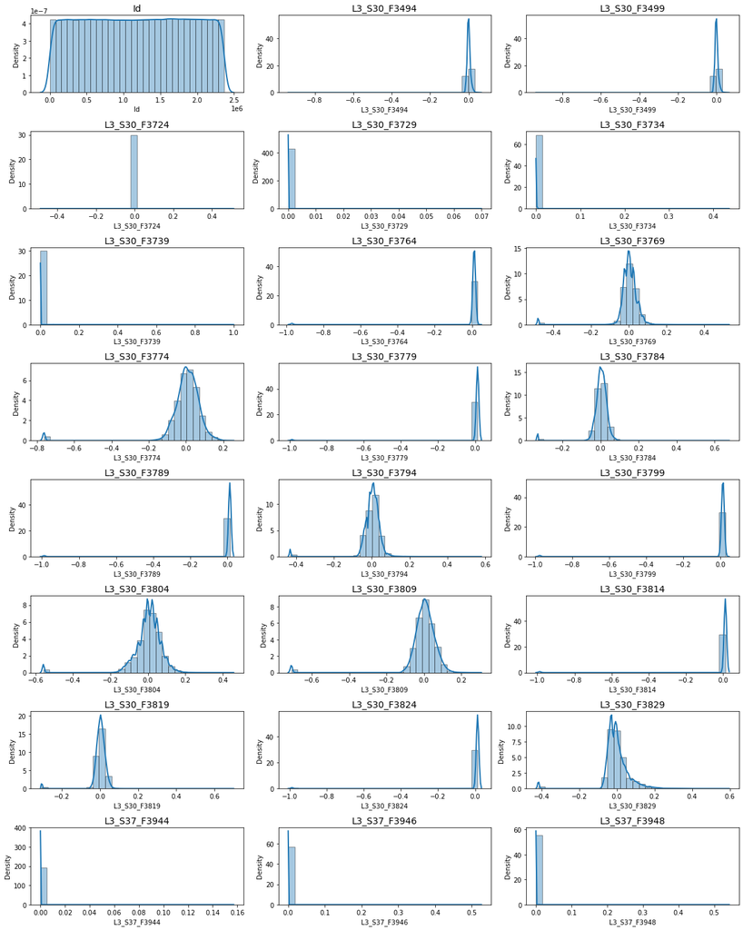

```python
# CHECK DISTRIBUTION
def compare(data, name, fig, rows, cols):         # FUNCTION TO DISPLAY SEVERAL HISTOGRAMS (ONLINE)
    for i in range(len(data.columns[1:25])):            # DISTRIBUTION NOT VALID TO CATEGORICAL VARIABLE
        plt.figure(figsize = (10, 5))             # SET THE FIGURE SIZE
        plt.figure(fig)
        plt.subplot(rows, cols, i+1)              # 3 x 3 MATRIX
        sns.distplot(data.iloc[:,i], hist = True, kde = True, bins = 30,
                     hist_kws = {'edgecolor':'black'}, kde_kws = {'linewidth': 2})  # PLOT HISTOGRAMS WITH NUMBER OF BINS = 50
        plt.title(name[i], fontsize = 14)
    return

plt.figure(figsize = (16,20))
compare(bosch_drop_row, bosch_drop_row.columns, 1, 8, 3)
plt.tight_layout()                                # INCREASE THE SPACE BETWEEN PLOTS
plt.show()
```

## 4. OUTLIERS

Since there are some attributes that are not normally distributed, we cannot simply drop the outliers with common methods.

```python
# DETECT OUTLIERS
def detect_outlier_z_score(col):
    outliers = []
    for x in col:
        z_score = (x - np.mean(col))/np.std(col)
        if np.abs(z_score) > 3: outliers.append(x)  # 6-sigma for 99.99966%
    num_outlier = len(outliers)
    return num_outlier

def detect_outlier_IQR(col):
    outliers = []
    sorted(col)
    Q1, Q3 = np.nanpercentile(col,[25,75])
    lower_range = Q1 - (1.5* (Q3 - Q1))
    upper_range = Q3 + (1.5* (Q3 - Q1))
    for x in col:
        if x > upper_range or x < lower_range: outliers.append(x)
    num_outlier = len(outliers)
    return num_outlier

# DETECT MULTICOLLINEARITY
def calc_vif(X):
    vif = pd.DataFrame()
    vif["variables"] = X.columns
    vif["VIF"] = [variance_inflation_factor(X.values, i) for i in range(X.shape[1])]
    return(vif)
```

## 5. OVERVIEW

```python
# CHECK EACH COLUMN
check_bosch = bosch_drop_row
add = [(check_bosch.columns[i+1],                                               # column names
        len(check_bosch.iloc[:,i+1]),                                           # variable length
        check_bosch.iloc[:,i+1].isnull().sum(),                                 # number of missing
        len(check_bosch.iloc[:,i+1]) - check_bosch.iloc[:,i+1].isnull().sum(),  # number number of valid
        detect_outlier_IQR(check_bosch.iloc[:,i+1]),                            # detect outliers by IQR
        round(np.nanmean(check_bosch.iloc[:,i+1]),6),                           # calculate mean value
        np.nanmedian(check_bosch.iloc[:,i+1]),                                  # find median
        np.nanstd(check_bosch.iloc[:,i+1]),                                     # calculate standard deviation
        check_bosch.iloc[:,i+1].skew(axis = 0, skipna = True),                  # check skewness
        kurtosis(check_bosch.iloc[:,i], fisher = True))                         # check kurtosis value
       for i in range(len(check_bosch.columns[2:25]))]                          # for all variables in the dataset
bosch_count_org = pd.DataFrame(add,                                             # join them into dataframe
                               columns = ['Variable', 'Number of Rows','Number of Missing','Number of Effective Rows',
                                          'Number of Outliers (IQR)', 'Mean', 'Median', 'Standard Deviation',
                                          'Skewness', 'Kurtosis'])
bosch_count_org
```

|  | Variable | Number of Rows | Number of Missing | Number of Effective Rows | Number of Outliers (IQR) | Mean | Median | Standard Deviation | Skewness | Kurtosis |
| --- | --- | --- | --- | --- | --- | --- | --- | --- | --- | --- |
| 0 | L3_S30_F3494 | 1118908 | 0 | 1118908 | 47854 | 0.000021 | -0.001 | 0.008765 | -1.038504 | -1.201721 |
| 1 | L3_S30_F3499 | 1118908 | 0 | 1118908 | 47854 | 0.000021 | -0.001 | 0.008765 | -1.038504 | 236.212307 |
| 2 | L3_S30_F3724 | 1118908 | 0 | 1118908 | 7267 | 0.000002 | 0.000 | 0.001303 | 14.445028 | 236.212307 |
| 3 | L3_S30_F3729 | 1118908 | 0 | 1118908 | 839 | 0.000002 | 0.000 | 0.000136 | 309.909034 | 59786.336506 |
| 4 | L3_S30_F3734 | 1118908 | 0 | 1118908 | 9781 | 0.000044 | 0.000 | 0.001526 | 109.407727 | 125267.164553 |
| 5 | L3_S30_F3739 | 1118908 | 0 | 1118908 | 7350 | 0.000047 | 0.000 | 0.002852 | 174.802029 | 20647.761895 |
| 6 | L3_S30_F3764 | 1118908 | 0 | 1118908 | 16751 | -0.000075 | 0.012 | 0.110250 | -8.668522 | 39006.560869 |
| 7 | L3_S30_F3769 | 1118908 | 0 | 1118908 | 31391 | 0.000093 | 0.005 | 0.063368 | -5.418870 | 73.197447 |
| 8 | L3_S30_F3774 | 1118908 | 0 | 1118908 | 26859 | 0.000076 | 0.009 | 0.102712 | -5.149853 | 39.395294 |
| 9 | L3_S30_F3779 | 1118908 | 0 | 1118908 | 14292 | 0.000227 | 0.013 | 0.112294 | -8.677687 | 36.192995 |
| 10 | L3_S30_F3784 | 1118908 | 0 | 1118908 | 25257 | 0.000331 | 0.005 | 0.045252 | -4.958267 | 73.302051 |
| 11 | L3_S30_F3789 | 1118908 | 0 | 1118908 | 14292 | 0.000227 | 0.013 | 0.112294 | -8.677687 | 34.535477 |
| 12 | L3_S30_F3794 | 1118908 | 0 | 1118908 | 29898 | 0.000041 | 0.005 | 0.058281 | -4.986809 | 73.302051 |
| 13 | L3_S30_F3799 | 1118908 | 0 | 1118908 | 35938 | 0.000002 | 0.013 | 0.110838 | -8.666258 | 35.786616 |
| 14 | L3_S30_F3804 | 1118908 | 0 | 1118908 | 35228 | 0.000086 | 0.007 | 0.085407 | -3.467147 | 73.171400 |
| 15 | L3_S30_F3809 | 1118908 | 0 | 1118908 | 23191 | 0.000039 | 0.007 | 0.092830 | -5.584392 | 21.028113 |
| 16 | L3_S30_F3814 | 1118908 | 0 | 1118908 | 14292 | 0.000227 | 0.013 | 0.112294 | -8.677687 | 40.697103 |
| 17 | L3_S30_F3819 | 1118908 | 0 | 1118908 | 21757 | 0.000233 | 0.003 | 0.040396 | -5.448292 | 73.302051 |
| 18 | L3_S30_F3824 | 1118908 | 0 | 1118908 | 14292 | 0.000227 | 0.013 | 0.112294 | -8.677687 | 39.509446 |
| 19 | L3_S30_F3829 | 1118908 | 0 | 1118908 | 73753 | 0.000044 | -0.007 | 0.071697 | -1.564911 | 73.302051 |
| 20 | L3_S37_F3944 | 1118908 | 0 | 1118908 | 142 | 0.000001 | 0.000 | 0.000188 | 595.916676 | 14.619567 |
| 21 | L3_S37_F3946 | 1118908 | 0 | 1118908 | 427 | 0.000004 | 0.000 | 0.000991 | 429.993096 | 453015.574489 |
| 22 | L3_S37_F3948 | 1118908 | 0 | 1118908 | 3219 | 0.000025 | 0.000 | 0.001217 | 165.904998 | 199468.006798 |